# Water Quality at Fingal Beaches

David Skerritt

2025-03-03

```r
library(tidyverse)
water <- read_csv(here::here( "Data","BathingWaterQuality2013.csv"))
water <- mutate(water,Date= lubridate::dmy(Date))
water4 <- filter(water, Beach %in% c("Sutton", "Portmarnock" ,"Skerries" ,"Howth - Claremont"))
```

Question 2 a.

## Readings per beach and Mean values

```r
# count number of readings for each beach
water |> count(Beach)
```

```
## # A tibble: 12 × 2
##    Beach                             n
##    <chr>                         <int>
##  1 Balbriggan                        8
##  2 Donabate                          8
##  3 Howth - Claremont                 8
##  4 Loughshinny                       8
##  5 Malahide                          8
##  6 Portmarnock                       8
##  7 Portrane - Burrow (The Brook)     8
##  8 Portrane - Tower Bay              8
##  9 Rush - North Beach                8
## 10 Rush - South Beach                8
## 11 Skerries                          8
## 12 Sutton                            8
```

```r
# calculate the mean E_Coli and mean Enterococci for the beaches.

water |>
  group_by(Beach) |>
  summarise(meanEcoli = mean(E_Coli),
            meanEnteroc = mean(Enterococci))
```

```
## # A tibble: 12 × 3
##    Beach                         meanEcoli meanEnteroc
##    <chr>                             <dbl>       <dbl>
##  1 Balbriggan                         72.5       23.5
##  2 Donabate                           31.9        9.25
##  3 Howth - Claremont                  66.6       38.4
##  4 Loughshinny                        42         11.1
##  5 Malahide                           25.8       10.8
##  6 Portmarnock                        68.4        7.75
##  7 Portrane - Burrow (The Brook)      20.5        3.88
##  8 Portrane - Tower Bay               10          4.12
##  9 Rush - North Beach                 53.8       14
## 10 Rush - South Beach                 20.4        5.12
## 11 Skerries                           12.5       10.2
## 12 Sutton                             13.9       11.9
```

## Summer bacteria levels for each beach

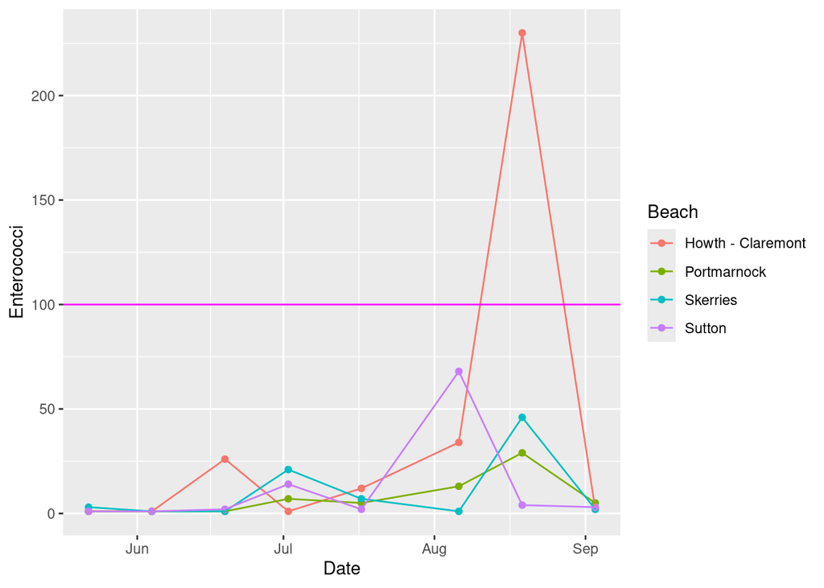

```r
#(b)

ggplot(water4, aes(x= Date, y= Enterococci, color = Beach))+
  geom_point()+
  geom_line()+
  geom_hline(yintercept=100, color="magenta")
```

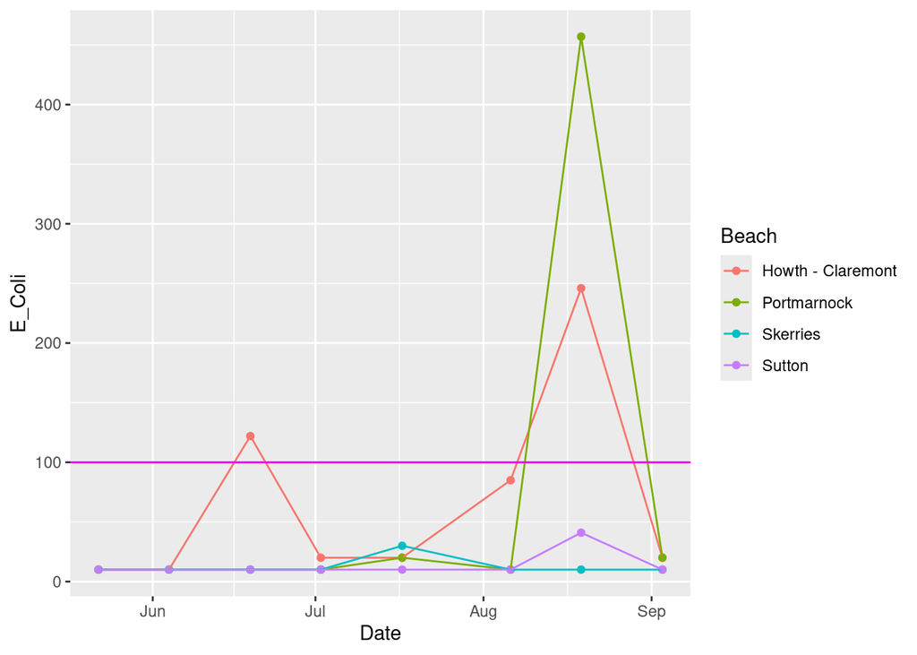

```r
ggplot(water4, aes(x= Date, y= E_Coli, color = Beach))+
  geom_point()+
  geom_line()+
  geom_hline(yintercept=100, color="magenta")
```

Which beach has the highest readings? Do any of the beaches exceed the guidelines? If so which beach and when?

For the bacteria Enterococci, the beach with the highest reading is Howth - Claremont at a count of over 225 per 100ml in mid August. This beach is the only one to exceed the guidelines (August). Sutton beach is the second highest (end of July, start of August) however it is within the guideline at roughly 65 per 100ml.

For the bacteria E.Coli, the beach with the highest reading is Portmarnock with a reading of over 450 per 100ml. This reading exceeded the guideline in August. The second highest reading is Howth-Claremont with 250 per 100ml. This reading exceeded the guideline in August, however the guideline was also exceeded in mid June with 120 per 100ml.

## Facet

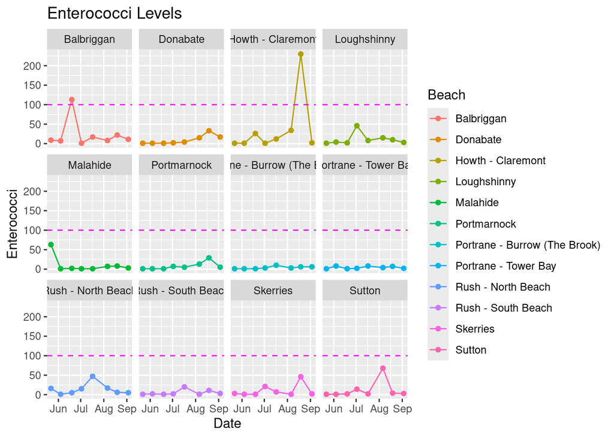

```r
# Plot Enterococci vs. Date for all beaches with facet_wrap
ggplot(water, aes(x = Date, y = Enterococci, color = Beach)) +
  geom_point() +
  geom_line() +
  geom_hline(yintercept = 100, color = "magenta", linetype = "dashed") +
  labs(title = "Enterococci Levels") +
  facet_wrap(vars(Beach))
```

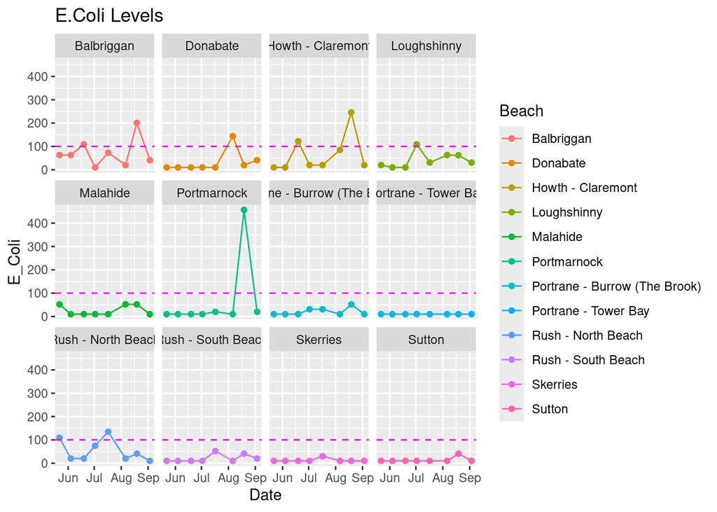

```r
# Plot Enterococci vs. Date for all beaches with facet_wrap
ggplot(water, aes(x = Date, y = E_Coli, color = Beach)) +
  geom_point() +
  geom_line() +
  geom_hline(yintercept = 100, color = "magenta", linetype = "dashed") +
  labs(title = "E.Coli Levels") +
  facet_wrap(vars(Beach))
```

e.

## Facet overlay

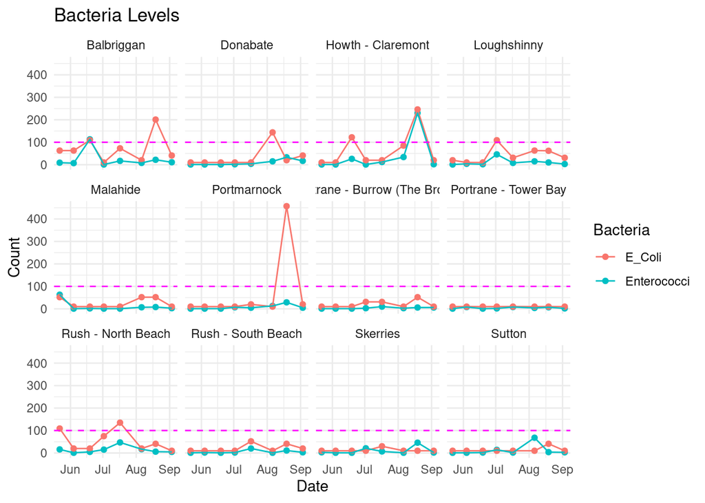

```r
# Melt the dataset to a long format to facilitate overlaid plotting
water_long <- water %>%
  select(Date, Beach, Enterococci, E_Coli) %>%
  pivot_longer(cols = c(Enterococci, E_Coli), names_to = "Bacteria", values_to = "Count")

# Plot Enterococci and E_Coli vs. Date for all beaches with different colors
ggplot(water_long, aes(x = Date, y = Count, color = Bacteria)) +
  geom_point() +
  geom_line() +
  geom_hline(yintercept = 100, color = "magenta", linetype = "dashed") +
  labs(title = "Bacteria Levels") +
  theme_minimal() +
  facet_wrap(vars(Beach))
```

For the beaches Rush - South Beach, Skerries, Sutton, Portrane - Tower Bay, Portrane - Burrow and Malahide, the water quality is mostly excellent and well below the guideline value from June to September. However there are a few instances where bacteria levels show an increase, such as June and August in Malahide or August in Sutton.

The reamining beaches have at least one instance of breaking the guideline. Portmarnock for example had excellent water all summer except mid August where a significantly high reading of E.Coli was recorded.

Question 3 a.

## Histograms

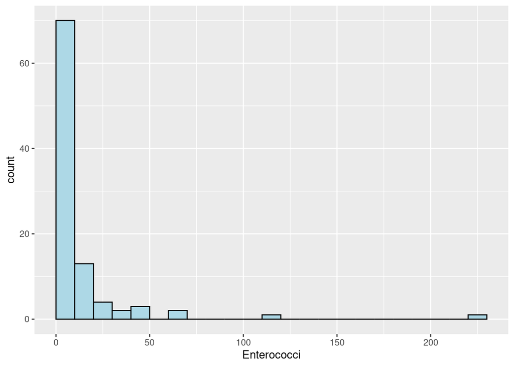

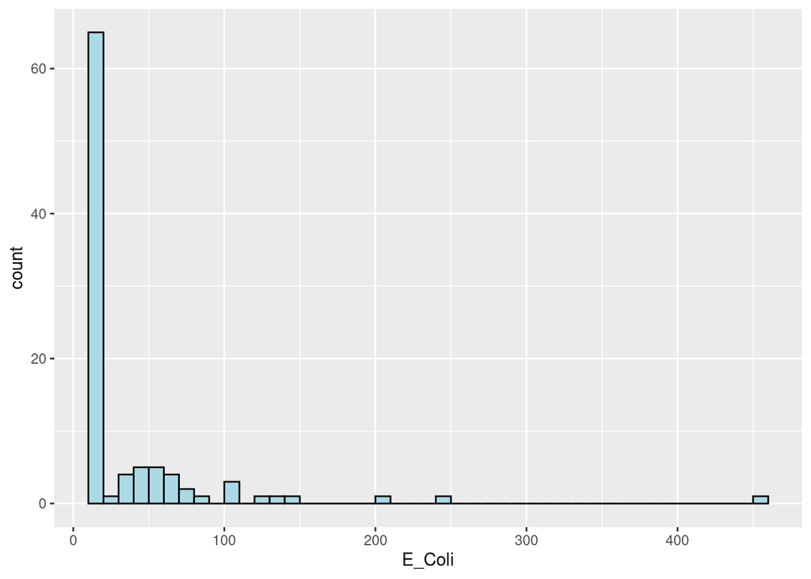

```r
ggplot(water, aes(x=Enterococci))+
  geom_histogram(fill="lightblue", color="black", binwidth=10, boundary=0)

ggplot(water, aes(x=E_Coli))+
  geom_histogram(fill="lightblue", color="black", binwidth=10, boundary=0)
```

b.

## Boxplots

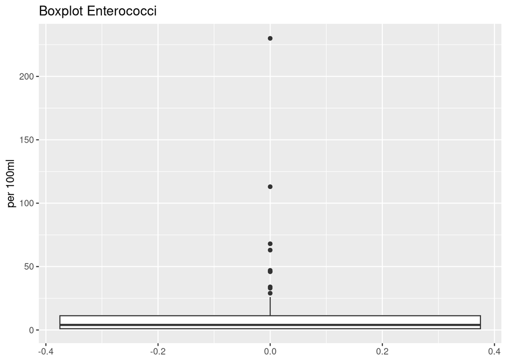

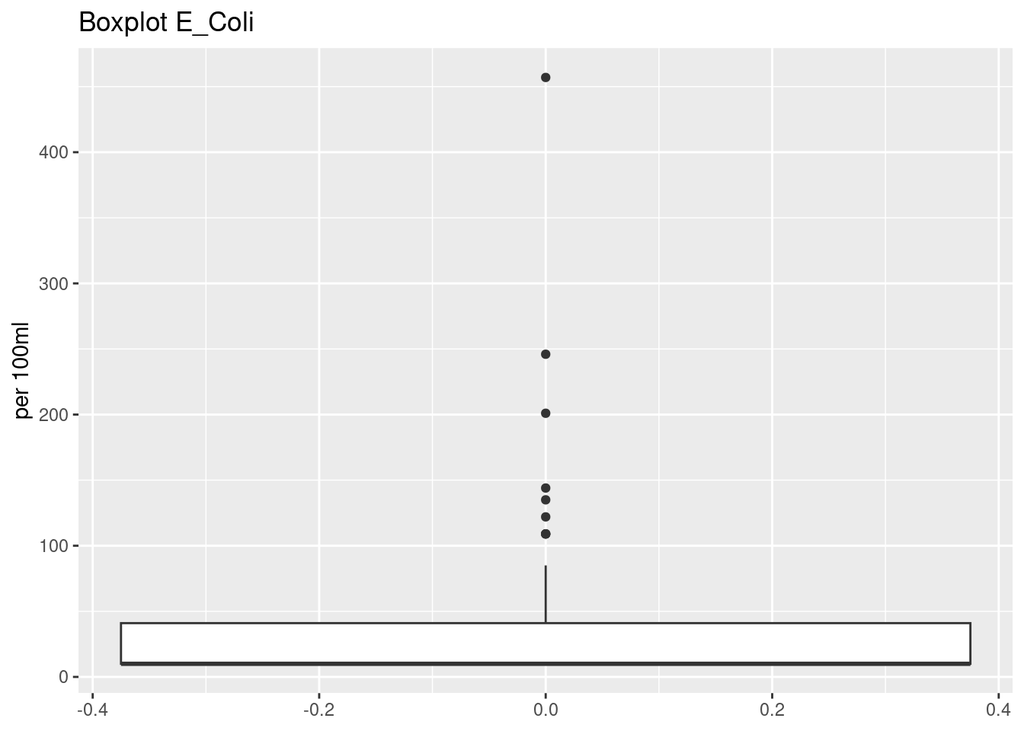

```r
ggplot(water, aes(y=Enterococci))+
  geom_boxplot()+
   labs(title = "Boxplot Enterococci", y = "per 100ml")

ggplot(water, aes(y=E_Coli))+
  geom_boxplot()+
  labs(title = "Boxplot E_Coli", y = "per 100ml")
```

## Boxplots side by side

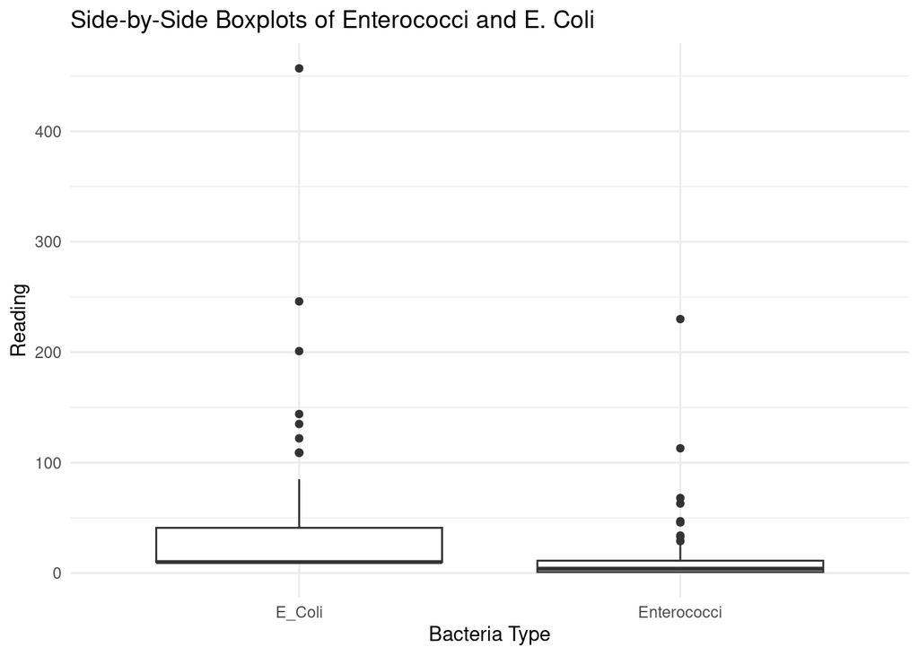

```r
library(tidyr)
waterlong <- water %>%
pivot_longer(c(Enterococci, E_Coli), names_to="Bacteria", values_to="Reading")

# Create the side-by-side boxplots
ggplot(waterlong, aes(x = Bacteria, y = Reading)) +
  geom_boxplot() +
  labs(title = "Side-by-Side Boxplots of Enterococci and E. Coli",
       x = "Bacteria Type", y = "Reading") +
  theme_minimal()
```

From the histograms, we can see that the data displays right skewness, which indicates that most of the readings are on the lower end of the scale (low levels of E.Coli and Enterococci). However there are instances where higher levels are recorded, as evidenced by the boxplot outliers.